# Predictive Models

### 1. Data Preparation

```r
# load the data
df1 <- read.csv('df1.csv')
df2 <- read.csv('df2.csv')
```

The workflow involves data splitting. The data will be divided into 3 parts, including training set (50%), validation set (25%) & testing set (25%). Each set is having its purposes as follows:

- **Training set:** it is used to build models. Additionally, Hyperparameter tuning is also carried out
- **Validation set:** it is used to choose the best cutoff/threshold which will differentiate the good credit from the bad one
- **Testing set:** it is used to evaluate the model’s performance.

```r
# split training set and test set
# instruction: https://cran.r-project.org/web/packages/caTools/caTools.pdf
# install.packages('caTools')
library(caTools)
set.seed(696)
split1 = sample.split(df1$credit, SplitRatio = 0.5)
training <- subset(df1, split1 == TRUE)
not_training <- subset(df1, split1 == FALSE)

split2 <- sample.split(not_training$credit, SplitRatio = 0.5)
testing <- subset(not_training, split2 == TRUE)
validation <- subset(not_training, split2 == FALSE)
```

```r
# number of observations in training set
nrow(training)
```

```
## [1] 318
```

```r
# number of observations in training set
nrow(validation)
```

```
## [1] 160
```

```r
# number of observations in test set: 160
nrow(testing)
```

```
## [1] 160
```

### 2. Decision Tree

```r
# instruction: https://cran.r-project.org/web/packages/caret/caret.pdf
# install.packages('caret')
library(caret)
library(rpart)
```

##### 2.1 hyperparameter tuning

```r
# setting conditions for trainControl
fitControl <- trainControl(method = "cv",   # set up cross validation
                           ## 5-fold cross validation
                           number = 5,
                           ## Estimate class probabilities
                           classProbs = TRUE,
                           ## Evaluate performance using the following function which
                           ## computes sensitivity, specificity & area under the ROC
                           summaryFunction = twoClassSummary)
```

```r
# search for parameter(s) for tuning random forest
modelLookup('rpart2')
```

```
##    model parameter          label forReg forClass probModel
## 1 rpart2  maxdepth Max Tree Depth   TRUE     TRUE      TRUE
```

```r
# setting different values of maxdepth for the model
man_grid <-  expand.grid(maxdepth = c(1:20))
# doing the grid search
set.seed(696)
tree_model1 <- train(credit ~.-id,
                     data = training,
                     method = "rpart2",
                     ## Specify which metric to optimize, by default, this is the accuracy
                     metric = "ROC",
                     trControl = fitControl,
                     tuneGrid = man_grid)
```

```r
tree_model1
```

```
## CART
##
## 318 samples
##  13 predictor
##   2 classes: 'Bad', 'Good'
##
## No pre-processing
## Resampling: Cross-Validated (5 fold)
## Summary of sample sizes: 255, 253, 255, 254, 255
## Resampling results across tuning parameters:
##
##   maxdepth  ROC        Sens       Spec
##    1        0.6403134  0.2806268  1.0000000
##    2        0.7705223  0.5156695  0.8546230
##    3        0.7705223  0.5156695  0.8546230
##    4        0.7794621  0.5310541  0.8492176
##    5        0.7746862  0.5458689  0.8229018
##    6        0.7666821  0.5150997  0.8391181
##    7        0.7694887  0.5304843  0.8174964
##    8        0.7597985  0.5527066  0.7856330
##    9        0.7556405  0.5603989  0.7748222
##   10        0.7556405  0.5603989  0.7748222
##   11        0.7556405  0.5603989  0.7748222
##   12        0.7556405  0.5603989  0.7748222
##   13        0.7556405  0.5603989  0.7748222
##   14        0.7556405  0.5603989  0.7748222
##   15        0.7556405  0.5603989  0.7748222
##   16        0.7556405  0.5603989  0.7748222
##   17        0.7556405  0.5603989  0.7748222
##   18        0.7556405  0.5603989  0.7748222
##   19        0.7556405  0.5603989  0.7748222
##   20        0.7556405  0.5603989  0.7748222
##
## ROC was used to select the optimal model using the largest value.
## The final value used for the model was maxdepth = 4.
```

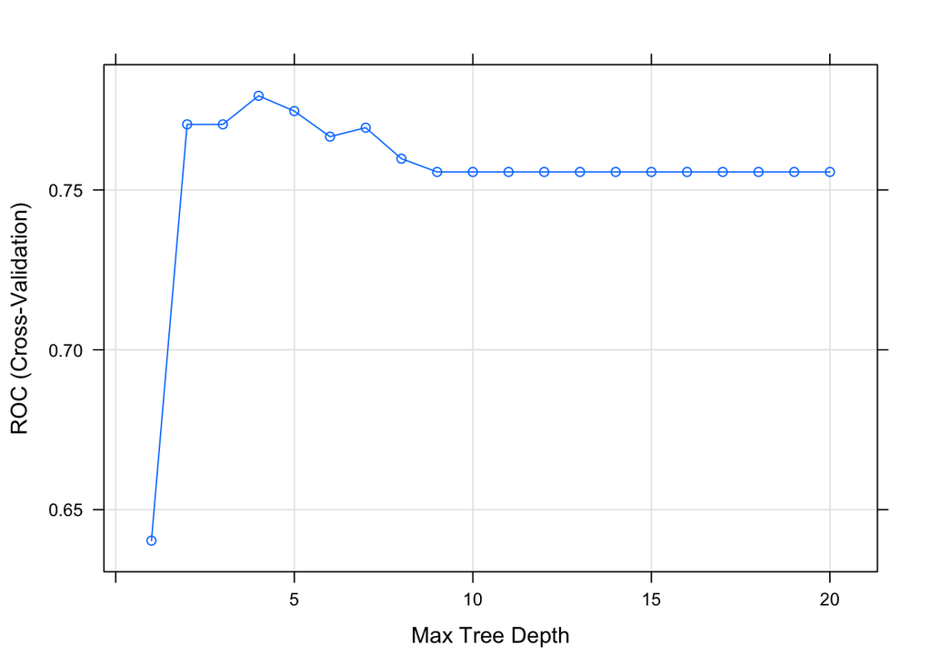

```r
plot(tree_model1)
```

At the maxdepth of 4, tree model will yield the best area under the curve (AUC)

##### 2.2 building the model

```r
# build the model by manually selecting the parameter after the grid search
# setting conditions for trainControl
fitControl <- trainControl(method = "cv",   # set up cross validation
                           ## 5-fold cross validation
                           number = 5,
                           ## Estimate class probabilities
                           classProbs = TRUE,
                           ## Evaluate performance using the following function which
                           ## computes sensitivity, specificity & area under the ROC
                           summaryFunction = twoClassSummary)
```

```r
# choosing maxdepth = 4 as the best tree model is given by doing the grid search above
hyperparams <- expand.grid(maxdepth = 4)
```

```r
# building the model
set.seed(696)
tree_model2 <- train(credit ~.-id,
                     data = training,
                     method = "rpart2",
                     tuneGrid = hyperparams,
                     metric = "ROC",
                     trControl = fitControl)
```

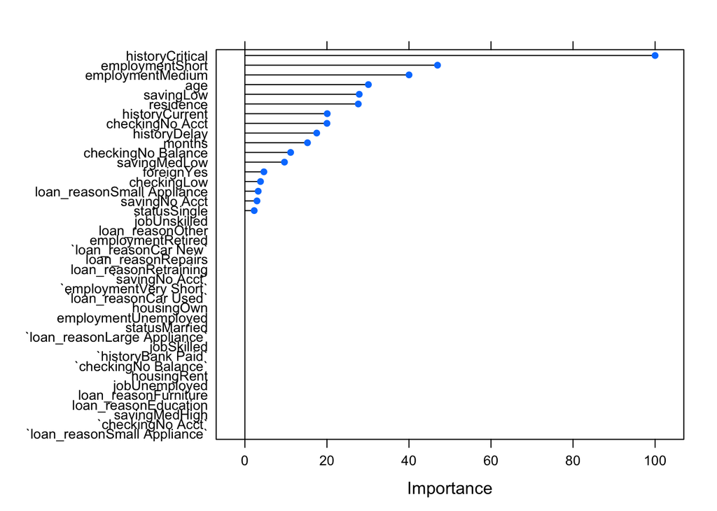

```r
plot(varImp(tree_model2))
```

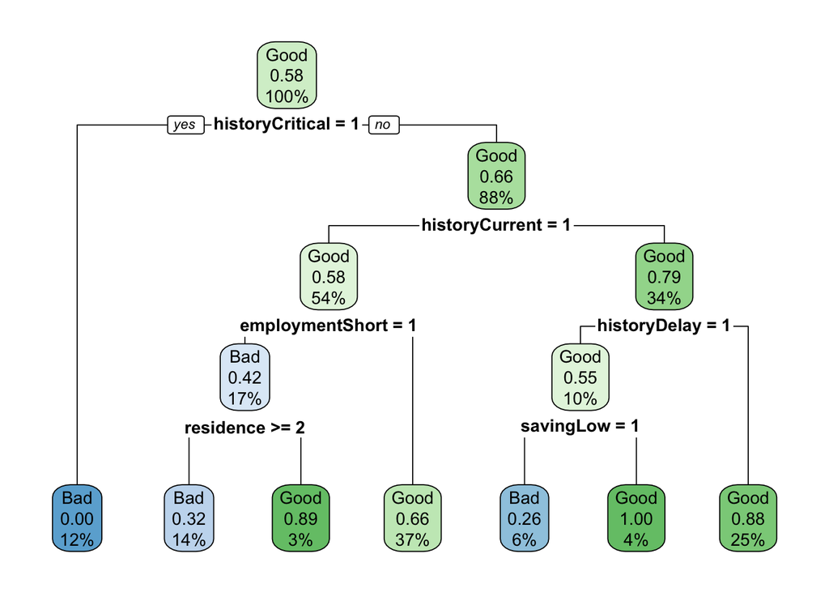

```r
rpart.plot::rpart.plot(tree_model2$finalModel)
```

##### 2.3 using validation set to choose the best threshold

```r
# extracting class posterior probabilities
prob <- predict(tree_model2, newdata = validation, type = 'prob')
# creating a vector of probability from tree prediction on the validation set
tree_val_prob <- prob[[2]]
```

```r
# choosing the best therold for the classifer
library(ROCR)
threshold_pred <- prediction(tree_val_prob, validation$credit)
evaluation <- performance(threshold_pred, 'acc')
# Identify the best threshold
max <- which.max(evaluation@y.values[[1]])
val_accuracy <- evaluation@y.values[[1]][max]
tree_threshold <- evaluation@x.values[[1]][max]
# reduce the threshold value a small degree so that the model could cover the true positives better
tree_threshold <- tree_threshold - 0.001
```

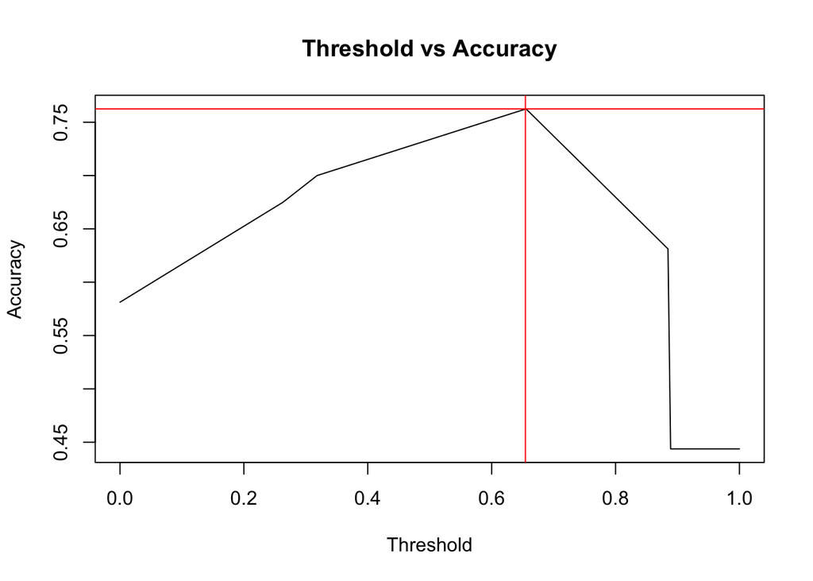

```r
plot(evaluation, main = 'Threshold vs Accuracy', xlab = 'Threshold', ylab = 'Accuracy')
abline(h = val_accuracy, col = 'red')
abline(v = tree_threshold, col = 'red')
```

```r
# the threshold value for tree model
tree_threshold
```

```
## [1] 0.6544622
```

##### 2.4 test the model on testing set

```r
# extracting class posterior probabilities
prob <- predict(tree_model2, newdata = testing, type = 'prob')
# creating a vector of probability from tree prediction on the validation set
tree_test_prob <- prob[[2]]
tree_test_pred <- as.factor(ifelse(prob[[2]] >= tree_threshold, "Good", "Bad"))
```

```r
# accuracy of the model on the testing set = 78.75%
confusionMatrix(testing$credit, tree_test_pred, positive = 'Good')
```

```
## Confusion Matrix and Statistics
##
##           Reference
## Prediction Bad Good
##       Bad   45   21
##       Good  13   81
##
##                Accuracy : 0.7875
##                  95% CI : (0.7159, 0.8481)
##     No Information Rate : 0.6375
##     P-Value [Acc > NIR] : 2.981e-05
##
##                   Kappa : 0.5535
##
##  Mcnemar's Test P-Value : 0.2299
##
##             Sensitivity : 0.7941
##             Specificity : 0.7759
##          Pos Pred Value : 0.8617
##          Neg Pred Value : 0.6818
##              Prevalence : 0.6375
##          Detection Rate : 0.5062
##    Detection Prevalence : 0.5875
##       Balanced Accuracy : 0.7850
##
##        'Positive' Class : Good
##
```

```r
tree_test_acc <- confusionMatrix(testing$credit, tree_test_pred, positive = 'Good')[[3]][[1]]
tree_test_sens <- confusionMatrix(testing$credit, tree_test_pred, positive = 'Good')[[4]][[1]]
tree_test_spec <- confusionMatrix(testing$credit, tree_test_pred, positive = 'Good')[[4]][[2]]
```

##### 2.5 making predictions on df2, i.e. scoring sheet

```r
df2$tree_prob <- predict(tree_model2, newdata = df2, type = 'prob')[[2]]
df2$tree_pred <- as.factor(ifelse(df2$tree_prob >= tree_threshold, "Good", "Bad"))
df2[,c('id','tree_pred')]
```

```
##     id tree_pred
## 1  781      Good
## 2  782      Good
## 3  783      Good
## 4  784      Good
## 5  785      Good
## 6  786      Good
## 7  787      Good
## 8  788      Good
## 9  789      Good
## 10 790      Good
## 11 791       Bad
## 12 792       Bad
## 13 793       Bad
```

### 3. Random Forest

```r
# install.packages('rpart')
library(rpart)
```

##### 3.1 hyperparameter tuning

```r
# setting conditions for trainControl
fitControl <- trainControl(method = "cv",   # set up cross validation
                           ## 3-fold cross validation
                           number = 5,
                           ## Estimate class probabilities
                           classProbs = TRUE,
                           ## Evaluate performance using the following function which
                           ## computes sensitivity, specificity & area under the ROC
                           summaryFunction = twoClassSummary)
```

```r
# search for parameter(s) for tuning random forest
modelLookup('rf')
```

```
##   model parameter                         label forReg forClass probModel
## 1    rf      mtry #Randomly Selected Predictors   TRUE     TRUE      TRUE
```

```r
# setting different values of mtry for the model
man_grid <-  expand.grid(mtry = c(1:13))
```

```r
# doing the grid search
set.seed(696)
# building the model                        NB. This takes some time to run
forest_model1 <- train(credit ~.-id,
                       data = training,
                       method = "rf",
                       ## Specify which metric to optimize, by default, this is the accuracy
                       metric = "ROC",
                       trControl = fitControl,
                       verbose = FALSE,
                       tuneGrid = man_grid)
```

```r
forest_model1
```

```
## Random Forest
##
## 318 samples
##  13 predictor
##   2 classes: 'Bad', 'Good'
##
## No pre-processing
## Resampling: Cross-Validated (5 fold)
## Summary of sample sizes: 255, 253, 255, 254, 255
## Resampling results across tuning parameters:
##
##   mtry  ROC        Sens        Spec
##    1    0.7106943  0.02279202  1.0000000
##    2    0.7191057  0.36410256  0.9085349
##    3    0.7212636  0.46267806  0.8711238
##    4    0.7131676  0.50085470  0.8495021
##    5    0.7103831  0.51623932  0.8227596
##    6    0.7147222  0.52393162  0.8281650
##    7    0.7139599  0.51595442  0.8177809
##    8    0.7119549  0.52364672  0.8122333
##    9    0.7181337  0.53133903  0.8281650
##   10    0.7170067  0.51623932  0.8176387
##   11    0.7202806  0.51623932  0.8173542
##   12    0.7162032  0.54615385  0.8174964
##   13    0.7189461  0.50883191  0.8229018
##
## ROC was used to select the optimal model using the largest value.
## The final value used for the model was mtry = 3.
```

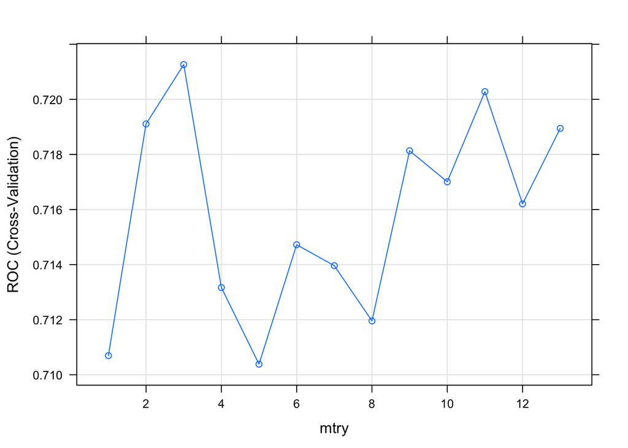

```r
plot(forest_model1, xlab = 'mtry')
```

The final value used for the model was mtry = 3.

```r
forest_model1$bestTune    # mtry = 3
```

```
##   mtry
## 3    3
```

##### 3.2 building the model

```r
# build the model by selecting the mtry given by the grid searches (mtry = 3)
hyperparams <- expand.grid(mtry=3)
fitControl <- trainControl(method = "cv",   # set up cross validation
                           ## 5-fold cross validation
                           number = 5,
                           ## Estimate class probabilities
                           classProbs = TRUE,
                           ## Evaluate performance using the following function which
                           ## computes sensitivity, specificity & area under the ROC
                           summaryFunction = twoClassSummary)
set.seed(696)
forest_model2 <- train(credit ~.-id,
                       data = training,
                       method = 'rf',
                       tuneGrid = hyperparams,
                       metric = "ROC",
                       trControl = fitControl,
                       verbose = F)
forest_model2
```

```
## Random Forest
##
## 318 samples
##  13 predictor
##   2 classes: 'Bad', 'Good'
##
## No pre-processing
## Resampling: Cross-Validated (5 fold)
## Summary of sample sizes: 255, 253, 255, 254, 255
## Resampling results:
##
##   ROC        Sens       Spec
##   0.7071055  0.4558405  0.8499289
##
## Tuning parameter 'mtry' was held constant at a value of 3
```

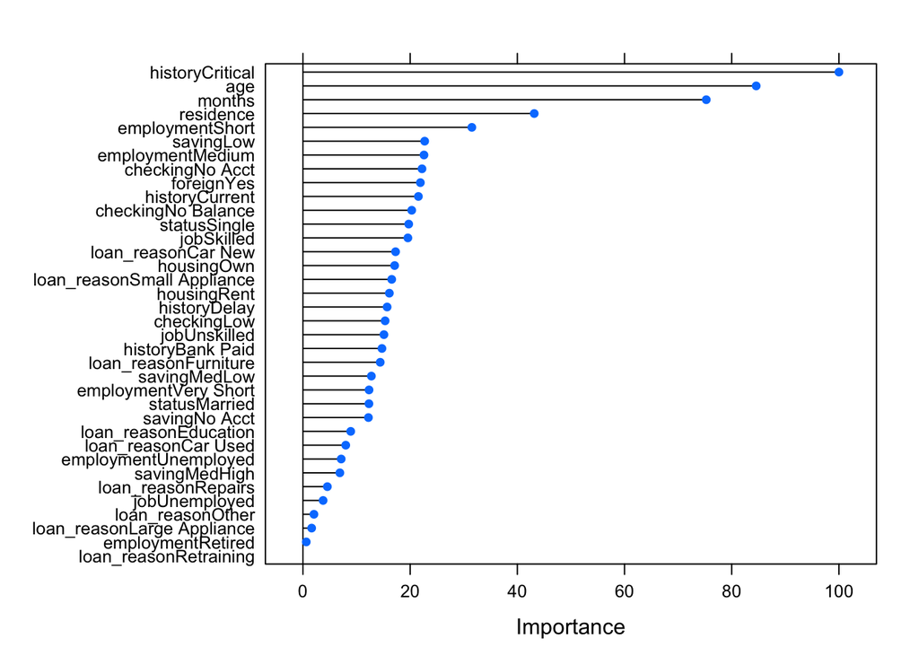

```r
forest_var <- varImp(forest_model2)
plot(forest_var)
```

##### 3.3 using validation set to choose the best threshold

```r
# extracting class posterior probabilities
prob <- predict(forest_model2, newdata = validation, type = 'prob')
# creating a vector of probability from tree prediction on the validation set
forest_val_prob <- prob[[2]]

# choosing the best therold for the classifer
library(ROCR)
threshold_pred <- prediction(forest_val_prob, validation$credit)
evaluation <- performance(threshold_pred, 'acc')
# Identify the best threshold
max <- which.max(evaluation@y.values[[1]])
val_accuracy <- evaluation@y.values[[1]][max]
forest_threshold <- evaluation@x.values[[1]][max]
# reduce the threshold value a small degree so that the model could cover the true positives better
forest_threshold <- forest_threshold - 0.001
```

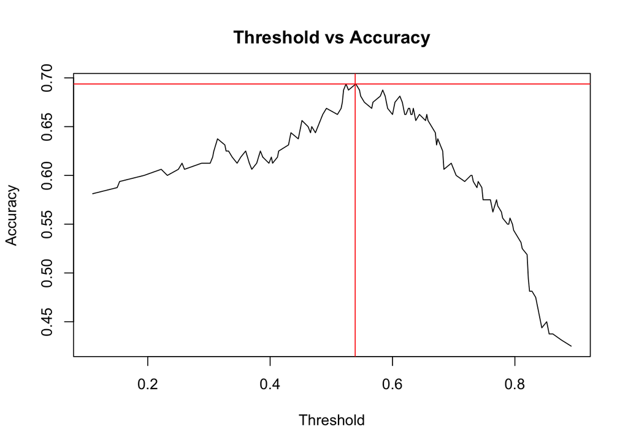

```r
plot(evaluation, main = 'Threshold vs Accuracy', xlab = 'Threshold', ylab = 'Accuracy')
abline(h = val_accuracy, col = 'red')
abline(v = forest_threshold, col = 'red')
```

```r
forest_threshold
```

```
## [1] 0.539
```

##### 3.4 test the model on testing set

```r
# extracting class posterior probabilities
prob <- predict(forest_model2, newdata = testing, type = 'prob')
# creating a vector of probability from tree prediction on the validation set
forest_test_prob <- prob[[2]]
forest_test_pred <- as.factor(ifelse(prob[[2]] >= forest_threshold, "Good", "Bad"))
# accuracy level of the model on the testing set = 64%
confusionMatrix(testing$credit, forest_test_pred, positive = 'Good')
```

```
## Confusion Matrix and Statistics
##
##           Reference
## Prediction Bad Good
##       Bad   29   37
##       Good  21   73
##
##                Accuracy : 0.6375
##                  95% CI : (0.5579, 0.7119)
##     No Information Rate : 0.6875
##     P-Value [Acc > NIR] : 0.92499
##
##                   Kappa : 0.2241
##
##  Mcnemar's Test P-Value : 0.04888
##
##             Sensitivity : 0.6636
##             Specificity : 0.5800
##          Pos Pred Value : 0.7766
##          Neg Pred Value : 0.4394
##              Prevalence : 0.6875
##          Detection Rate : 0.4562
##    Detection Prevalence : 0.5875
##       Balanced Accuracy : 0.6218
##
##        'Positive' Class : Good
##
```

```r
forest_test_acc <- confusionMatrix(testing$credit, forest_test_pred, positive = 'Good')[[3]][[1]]
forest_test_sens <- confusionMatrix(testing$credit, forest_test_pred, positive = 'Good')[[4]][[1]]
forest_test_spec <- confusionMatrix(testing$credit, forest_test_pred, positive = 'Good')[[4]][[2]]
```

##### 3.5 making predictions on df2, i.e. scoring sheet

```r
df2$forest_prob <- predict(forest_model2, newdata = df2, type = 'prob')[[2]]
df2$forest_pred <- as.factor(ifelse(df2$forest_prob >= forest_threshold, "Good", "Bad"))
df2[,c('id','tree_pred', 'forest_pred')]
```

```
##     id tree_pred forest_pred
## 1  781      Good        Good
## 2  782      Good        Good
## 3  783      Good        Good
## 4  784      Good        Good
## 5  785      Good        Good
## 6  786      Good        Good
## 7  787      Good        Good
## 8  788      Good        Good
## 9  789      Good        Good
## 10 790      Good        Good
## 11 791       Bad         Bad
## 12 792       Bad         Bad
## 13 793       Bad         Bad
```